# Text Analytics/Mining in Job Postings

Saul Ventura

Last update: 06 March, 2019

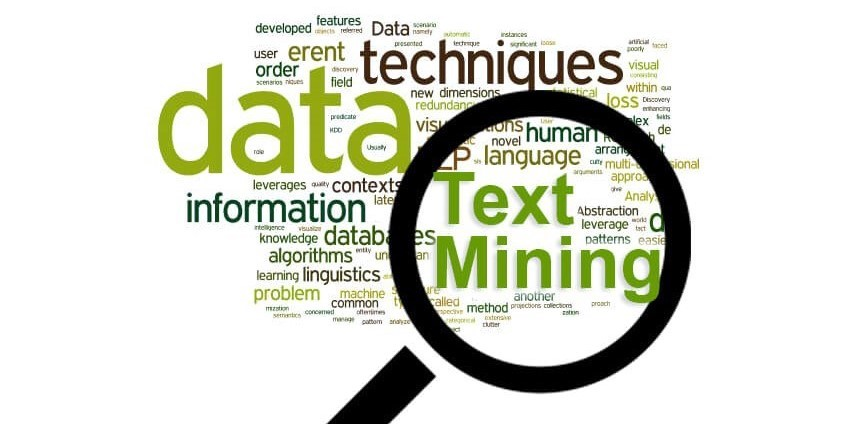

# 1 Introduction

## 1.2 Purpose

The main purpose of this project is to gain insights that can help job applicants to be familiar with what the organizations are looking for in terms of data scientist positions located in Los Angeles area.

## 1.3 High level approach

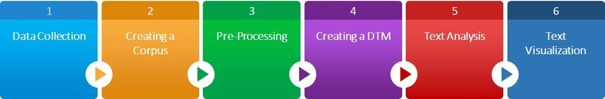

# 2 Data Collection

## 2.1 Library import

Loading libraries for this project life cycle: **data cleaning, processing & visualization…**

```r
# There are a range of packages in R for doing text analysis. These include:
#
# hunspell - Tools for spelling, stemming, and tokenization.
# SnowballC - Tools for stemming in a range of languages.
# stringr - Tools for cleaning individual strings (e.g. trimming whitespace).
# text2vec - Tools for tools for text vectorization, topic modeling, and more.
# tidytext - Tools for word processing, sentiment analysis, and tidying text.
# tm - A framework for text mining.
Sys.setenv(JAVA_HOME='C:\\Program Files (x86)\\Java\\jre1.8.0_45') # for 32-bit version

library(tm)
library(tmap)
library(SnowballC)
library(ggplot2)
library(DT)
library(plyr)
library(tibble)
library(RColorBrewer)
library(wordcloud)
library(stringr)
library(textstem)
library(RWeka)
library(qdap)
library(RColorBrewer)
library(udpipe)
library(lattice)
library(filematrix)
```

## 2.2 Data Loading

Loading **Job posting dataset…**

```r
# Setting my working directory in R
setwd("C:/Saul/Portfolio/Text Analytics")
# Reading the dataset

data.text  <- read.csv("DataScientistjobs.csv")
data.tools  <- read.csv("Tools.csv")

#yy <- matrix(t(as.matrix(as.data.frame(t(data.tools)))), nrow = 1)
```

## 2.3 Data Exploring

```r
#  Data structure review
#  str(data.text)
#  Data preview
```

Checking a **sample data…**

```r
datatable(data.text[(1:20),], filter = 'top', options = list(
  pageLength = 5, scrollX = TRUE, scrollY = "300px", autoWidth = TRUE))
```

|  | Title | Company | Description | Date | City |
| --- | --- | --- | --- | --- | --- |
| 1 | Data Scientist - Marketplace | NEXT Trucking | NEXT is a venture-backed tech startup on a mission to build the country’s largest and happiest virtual trucking fleet. Our mobile app powers the first trucker-centric marketplace designed to make it e… | 1/24/2019 | Los Angeles |
| 2 | Sr. Data Scientist | Taboola | Read something interesting online today? There's a good chance it reached you because of our technology. Taboola is the world's leading content discovery platform, serving 360B recommendations to over… | 1/24/2019 | Los Angeles |
| 3 | Data Scientist | Capgemini | Need a R shiny expert JD for R Shiny developer Job description Responsibilities include, but are not limited to, the following: Implement data solutions to disseminate and visualize datasets using con… | 1/24/2019 | Los Angeles |
| 4 | Data Scientist/Visualization Master | Intermedia Advertising | We are seeking a Manager of Business Intelligence (BI Guru/Data Scientist/Visualization Master) to become an integral part of our team! You will analyze data and build visualizations to better underst… | 1/23/2019 | Los Angeles |
| 5 | Data Scientist | Street Simplified | Undergraduate or graduate degree in computer science, electrical engineering, or related fields. Experience processing and pulling insight from large (GB – TB) datasets. Ability to scope and solve pro… | 1/21/2019 | Los Angeles |
| 6 | Applied Engineering Data Scientist | The Aerospace Corporation | A trusted partner. A national resource. A leader in national security space. We are THE Aerospace Corporation. A team that takes pride in our readiness to solve some of the most complex technical chal… | 1/21/2019 | Los Angeles |
| 7 | Sr. Data Scientist | Ample Insight, Inc. | Our team is composed of world-class data scientists and industry experts from Facebook, Uber, Microsoft, Google, amongst others. We are looking for Data Scientists who are passionate about Machine Lea… | 1/18/2019 | Los Angeles |
| 8 | Data Scientist | CGI Group, Inc. | Meet our professionals CGI: Committed to helping its professionals and clients Position Description: This position is responsible for business consulting activities for the Data Strategy and Analytics… | 1/18/2019 | Los Angeles |
| 9 | Data Scientist | MINDBODY, Inc | Data Scientists focus on extracting, understanding, manipulating and conveying complex data from MINDBODY’s production environment. This position works closely with their manager to prioritize tasks t… | 1/15/2019 | Los Angeles |
| 10 | Senior Data Scientist | Frontier Communications Corporation | Senior Data Scientist Frontier Communications Corporation (NASDAQ: FTR) is a leader in providing communications services to urban, suburban, and rural communities in 29 states. Frontier offers a varie… | 1/14/2019 | Los Angeles |

[output cut: 10 more lines]

# 3 Creating a Corpus

## 3.1 Corpus Preparation

The next step is to transform the dataset into a text document **using the function Corpus** that belongs to the **TM package**. Corpus is a function that takes a text document as input and returns a text document (a character vector). [Read more about TM.](https://cran.r-project.org/web/packages/tm/tm.pdf)

```r
# Create corpus
corpus = Corpus(VectorSource(data.text$Description))
# Look at corpus
print(corpus)
```

```
## <<SimpleCorpus>>
## Metadata:  corpus specific: 1, document level (indexed): 0
## Content:  documents: 43
```

# 4 Pre-Processing

Once we have a corpus, then we need to modify the documents in it, e.g., **puntuaction removal, stemming, stopword removal,*** etcetera.

```r
cleanCorpus <- function(corpus){
  # Converting to lower-case
  corpus.cleaned <- tm_map(corpus, tolower)
  # Removing punctuation
  corpus.cleaned <- tm_map(corpus.cleaned, removePunctuation)
  # Looking at stop words
  v_stopwords <- c(stopwords("en"),"will","etc","build","using","usemploymentcompliancecgicom","unless","vary","reason","routed","recruited")
  corpus.cleaned <- tm_map(corpus.cleaned, removeWords,v_stopwords )
  #Eliminating extra whitespace
  corpus.cleaned <- tm_map(corpus.cleaned, stripWhitespace)
  #Removing numbers
  corpus.cleaned <- tm_map(corpus.cleaned, removeNumbers)
  #Stemming/Lemmatizing document
  #corpus.cleaned <- tm_map(corpus.cleaned, lemmatize_strings,v_stopwords)
  #Removing special characters
  corpus.cleaned <- tm_map(corpus.cleaned, str_replace_all,"[^[:alnum:]]", " ")
  #corpus[[1]]$content
  return(corpus.cleaned)
}
corpus <- cleanCorpus(corpus)
```

# 5 Creating a TDM

Now let’s create a *Term Document Matrix (TDM).* A term-document matrix is a mathematical matrix that describes the frequency of terms that occur in a collection of documents. [This video concisely explains what TDM is.](https://www.youtube.com/watch?v=dE10fBCDWQc)

## 5.1 Convert corpus into TDM

Also, let’s **inspect** 10 terms that belong to 10 documents.

```r
#convert to document term matrix
corpustdm <- TermDocumentMatrix(corpus)
#print(corpustdm)
#print(dimnames(corpustdm)$Terms)
#dim(corpustdm)
inspect(corpustdm[1:10,1:10])
```

```
## <<TermDocumentMatrix (terms: 10, documents: 10)>>
## Non-/sparse entries: 24/76
## Sparsity           : 76%
## Maximal term length: 10
## Weighting          : term frequency (tf)
## Sample             :
##             Docs
## Terms        1 10 2 3 4 5 6 7 8 9
##   able       4  0 0 0 0 0 1 0 0 0
##   activities 1  0 0 1 0 0 0 0 2 0
##   alerts     1  0 0 0 0 0 0 0 0 0
##   allow      1  0 0 0 0 0 0 0 0 0
##   also       1  0 1 1 0 0 3 1 0 0
##   analysis   5  3 0 2 2 0 1 0 1 3
##   anova      1  0 0 0 0 0 0 0 0 0
##   app        3  0 0 0 0 0 0 0 0 0
##   apple      1  0 0 0 0 0 0 0 0 0
##   applying   1  0 0 0 0 0 0 1 0 0
```

# 6 Text Analysis

## 6.1 Frequency words

Checking the **number of terms**.

```r
#collapse matrix by summing over columns
set.seed(43)
colS <- colSums(as.matrix(t(corpustdm)))

#total number of terms
length(colS)
```

```
## [1] 2895
```

```r
# create sort order (asc)
ord <- order(colS,decreasing=TRUE)
```

Inspecting **most frequently** ocurring terms.

```r
colS[head(ord)]
```

```
##       data experience   learning   business    science    machine
##        491        233        144        143        121        114
```

Inspecting **least frequently** ocurring terms.

```r
colS[tail(ord)]
```

```
##     perceived    proceeding     recruiter     reference      returned
##             1             1             1             1             1
## transitioning
##             1
```

Listing terms that appear **at least 50 times**.

```r
findFreqTerms(corpustdm, lowfreq=50)
```

```
##  [1] "analysis"    "business"    "data"        "experience"  "learning"
##  [6] "machine"     "models"      "python"      "science"     "statistical"
## [11] "team"        "work"        "years"       "analytics"   "degree"
## [16] "scientist"   "solutions"   "develop"     "engineering" "skills"
## [21] "ability"     "working"
```

Let’s take some of the above terms and check if there is a **correlation** with other terms having a correlation coefficient of **at least 70%**.

```r
findAssocs(corpustdm, "analysis",0.7)
```

```
## $analysis
## presentations
##          0.78
```

```r
findAssocs(corpustdm, "degree",0.7)
```

```
## $degree
##    serve economic computer   gender
##     0.76     0.75     0.73     0.70
```

# 7 Text Visualization

## 7.1 Histogram

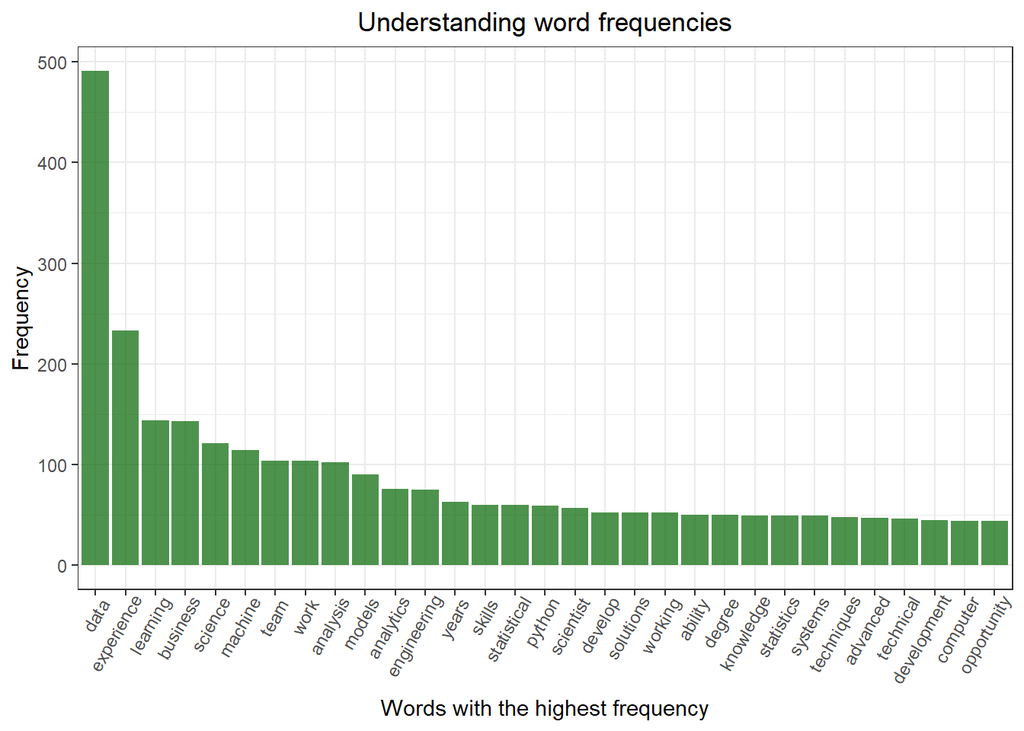

```r
m <- as.matrix(corpustdm)
corpusdf <- data.frame(m)

v <- sort(rowSums(m),decreasing=TRUE)
d <- data.frame(word = names(v),freq=v)

corpusdf <- rownames_to_column(corpusdf)
corpusdf <- rename(corpusdf, c("rowname"="word"))
corpusdf$wordcount <- rowSums(corpusdf[-1])
corpusdf <- corpusdf[order(-corpusdf$wordcount),]



#plotting histogram
ggplot(subset(corpusdf, wordcount>43), aes(reorder(word, -wordcount), wordcount)) +
   geom_bar(stat = "identity", fill = "darkgreen", alpha = 0.7) +
  xlab("Words with the highest frequency") +
  ylab("Frequency") +
  ggtitle("Understanding word frequencies") +
  theme_bw() +
  theme(axis.text.x=element_text(angle=60, hjust=0.9), plot.title = element_text(hjust=0.5)) +
 scale_fill_brewer()
```

## 7.2 Top 10 words

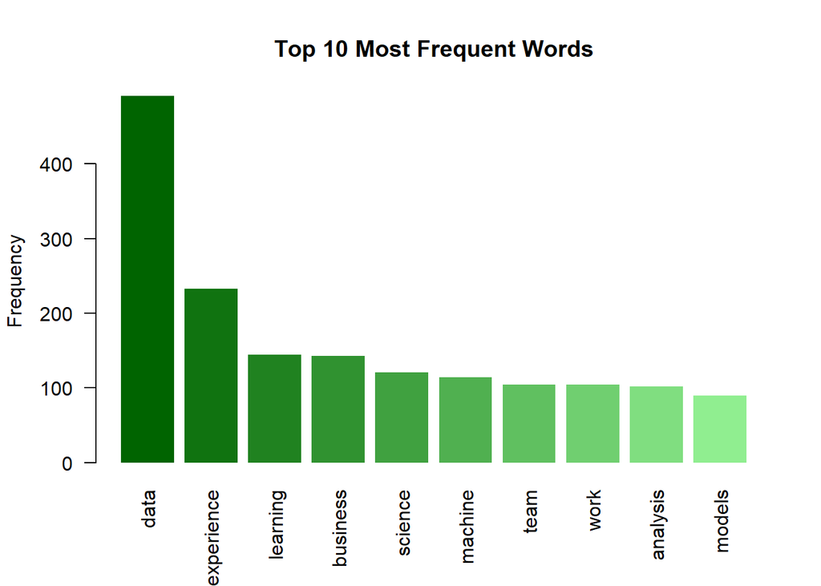

```r
pal <- colorRampPalette(colors = c("darkgreen", "lightgreen"))(10)

barplot(d[1:10,]$freq, las = 2, names.arg = d[1:10,]$word,
         main ="Top 10 Most Frequent Words",
        ylab = "Frequency", col = pal,  border = NA)
```

## 7.3 WordClouds

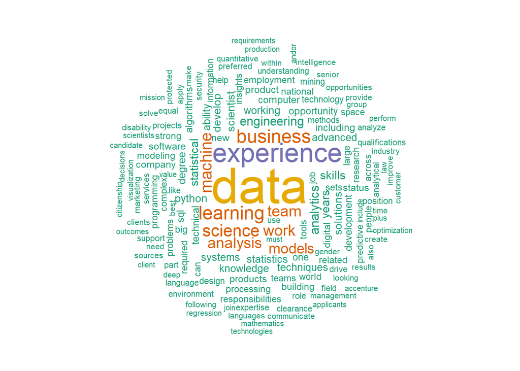

```r
# wordcloud(names(colS), colS, colors = brewer.pal(6, 'Dark2'),random.order=FALSE, rot.per= 0.35, max.words = 100)



#since all the rows are same and numeric,we can add them up to get the total value
#sort it based on the number

pal <- brewer.pal(9,"RdYlGn")
pal <- pal[-(1:2)]

set.seed(142)
wordcloud(word=corpusdf$word, freq= corpusdf$wordcount,  colors = brewer.pal(6, "Dark2"), random.order=FALSE, rot.per= 0.35, max.words = 150)
```

## 7.4 Universal Word Classes

### 7.4.1 Universal Parts of Speech

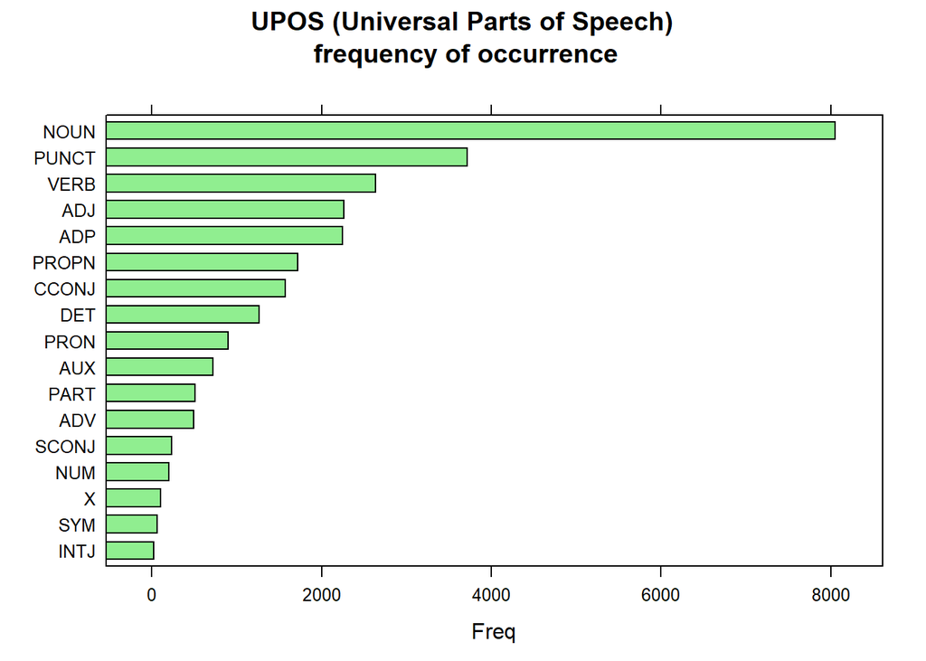

```r
#ud_model <- udpipe_download_model(language = "english")
#ud_model <- udpipe_load_model(ud_model$file_model)
ud_model <- udpipe_load_model(file = "english-ewt-ud-2.3-181115.udpipe")


x <- udpipe_annotate(ud_model, x = data.text$Description, doc_id = data.text$Company)
x <- as.data.frame(x)


stats <- txt_freq(x$upos)
stats$key <- factor(stats$key, levels = rev(stats$key))
barchart(key ~ freq, data = stats, col = "lightgreen",
         main = "UPOS (Universal Parts of Speech)\n frequency of occurrence",
         xlab = "Freq")
```

### 7.4.2 Adjectives

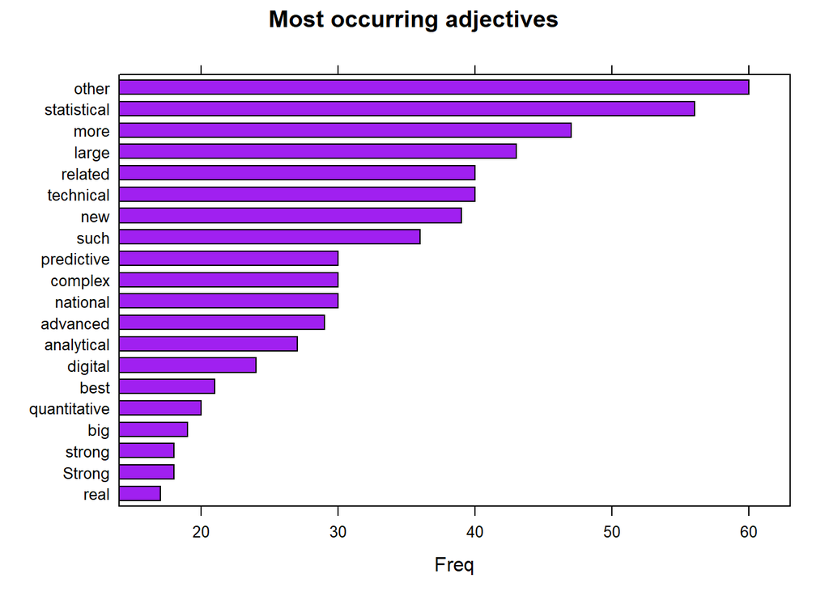

```r
## ADJECTIVES
stats <- subset(x, upos %in% c("ADJ"))
stats <- txt_freq(stats$token)
stats$key <- factor(stats$key, levels = rev(stats$key))
barchart(key ~ freq, data = head(stats, 20), col = "purple",
         main = "Most occurring adjectives", xlab = "Freq")
```

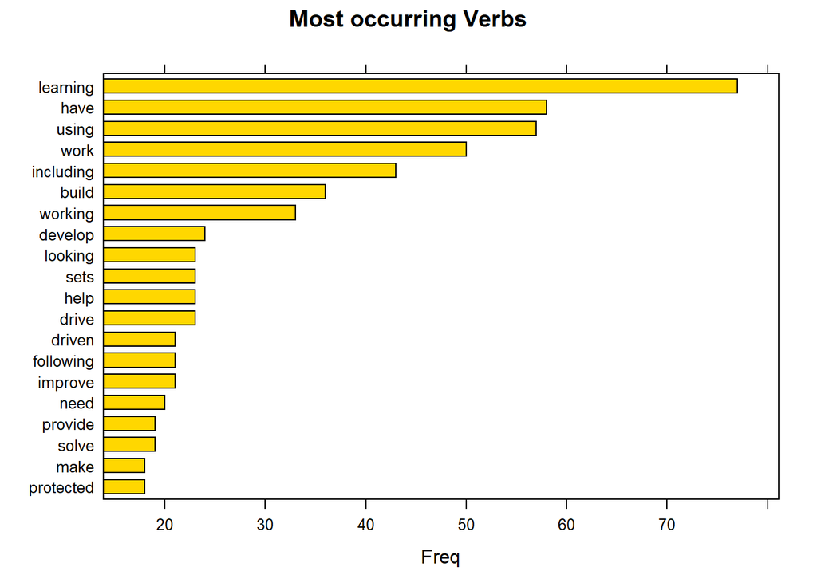

```r
## NOUNS
stats <- subset(x, upos %in% c("VERB"))
stats <- txt_freq(stats$token)
stats$key <- factor(stats$key, levels = rev(stats$key))
barchart(key ~ freq, data = head(stats, 20), col = "gold",
         main = "Most occurring Verbs", xlab = "Freq")
```

## 7.5 RAKE chart

Rapid Automatic Keyword Extraction **(RAKE)** is an algorithm to automatically extract keywords from documents. [More info here.](https://www.thinkinfi.com/2018/09/keyword-extraction-using-rake-in-python.html)

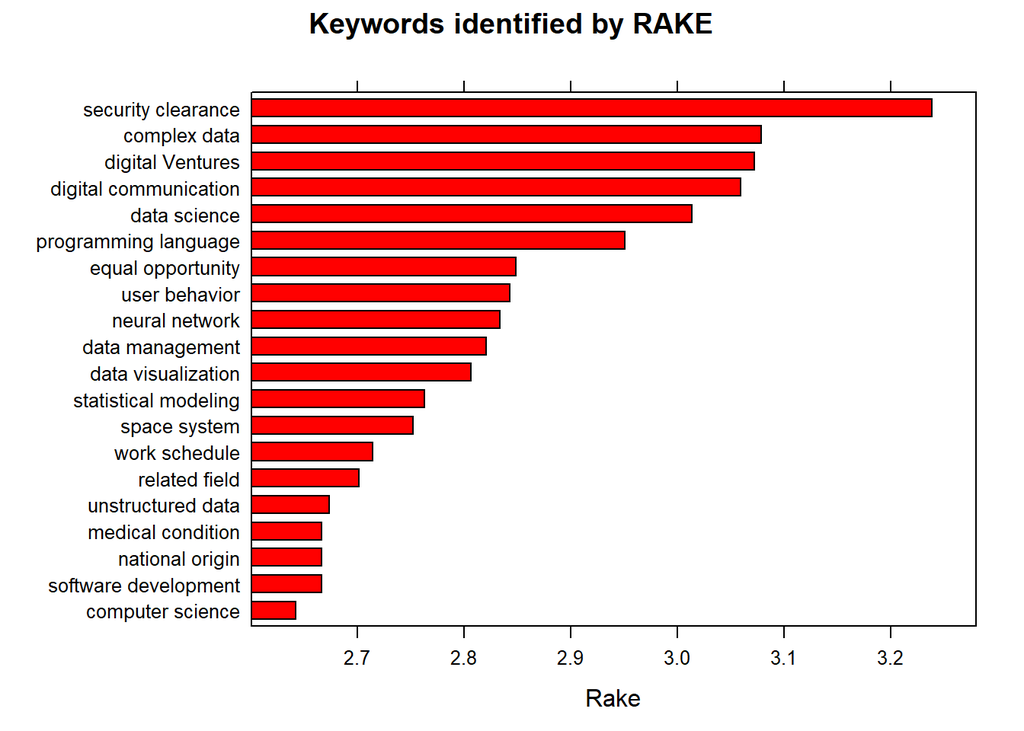

```r
## Using RAKE
#Rapid Automatic Keyword Extraction (RAKE) is an algorithm to automatically extract keywords from documents.
#More info on https://www.thinkinfi.com/2018/09/keyword-extraction-using-rake-in-python.html

stats <- keywords_rake(x = x, term = "lemma", group = "doc_id",
                       relevant = x$upos %in% c("NOUN", "ADJ"))
stats$key <- factor(stats$keyword, levels = rev(stats$keyword))
barchart(key ~ rake, data = head(subset(stats, freq > 3), 20), col = "red",
         main = "Keywords identified by RAKE",
         xlab = "Rake")
```

```r
# ## Using a sequence of POS tags (noun phrases / verb phrases)
# x$phrase_tag <- as_phrasemachine(x$upos, type = "upos")
# stats <- keywords_phrases(x = x$phrase_tag, term = tolower(x$token),
#                           pattern = "(A|N)*N(P+D*(A|N)*N)*",
#                           is_regex = TRUE, detailed = FALSE)
# stats <- subset(stats, ngram > 1 & freq > 3)
# stats$key <- factor(stats$keyword, levels = rev(stats$keyword))
# barchart(key ~ freq, data = head(stats, 20), col = "magenta",
#          main = "Keywords - simple noun phrases", xlab = "Frequency")
#
```

## 7.6 N-gram charts

### 7.6.1 Bigrams

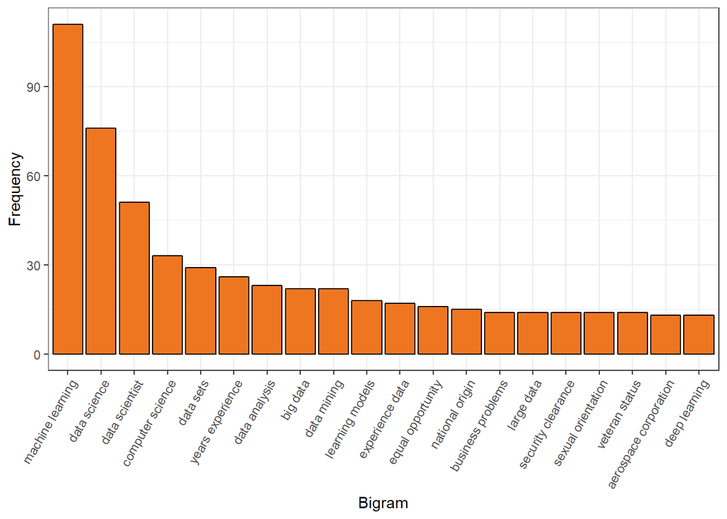

```r
library(dplyr)
library(tidytext)

# Define bigram & trigram tokenizer
tokenizer_bi <- function(x){
  NGramTokenizer(x, Weka_control(min=2, max=2))
}

tokenizer_tri <- function(x){
  NGramTokenizer(x, Weka_control(min=3, max=3))
}


# Text transformations
cleanVCorpus <- function(corpus){
  corpus.tmp <- tm_map(corpus, removePunctuation)
  corpus.tmp <- tm_map(corpus.tmp, stripWhitespace)
  corpus.tmp <- tm_map(corpus.tmp, content_transformer(tolower))
  v_stopwords <- c(stopwords("en"),"will","etc","build","using")
  corpus.tmp <- tm_map(corpus.tmp, removeWords, v_stopwords)
  corpus.tmp <- tm_map(corpus.tmp, removeNumbers)
  return(corpus.tmp)
}

# Most frequent bigrams
frequentBigrams <- function(text){
  s.cor <- VCorpus(VectorSource(text))
  s.cor.cl <- cleanVCorpus(s.cor)
  s.tdm <- TermDocumentMatrix(s.cor.cl, control=list(tokenize=tokenizer_bi))
  s.tdm <- removeSparseTerms(s.tdm, 0.999)
  m <- as.matrix(s.tdm)
  word_freqs <- sort(rowSums(m), decreasing=TRUE)
  dm <- data.frame(word=names(word_freqs), freq=word_freqs)
  return(dm)
}


# Most frequent bigrams
ep4.bigrams <- frequentBigrams(data.text$Description)[1:20,]
ggplot(data=ep4.bigrams, aes(x=reorder(word, -freq), y=freq)) +
  geom_bar(stat="identity", fill="chocolate2", colour="black") +
  theme_bw() +
  theme(axis.text.x=element_text(angle=60, hjust=1)) +
  labs(x="Bigram", y="Frequency")
```

### 7.6.2 Trigrams

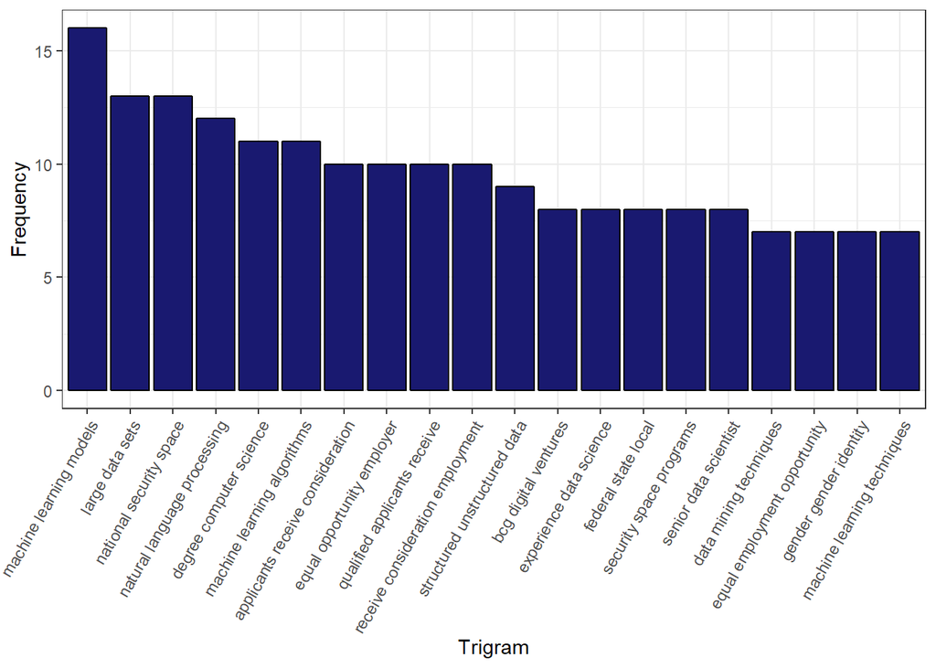

```r
# Most frequent trigrams
frequentTrigrams <- function(text){
  s.cor <- VCorpus(VectorSource(text))
  s.cor.cl <- cleanVCorpus(s.cor)
  s.tdm <- TermDocumentMatrix(s.cor.cl, control=list(tokenize=tokenizer_tri))
  s.tdm <- removeSparseTerms(s.tdm, 0.999)
  m <- as.matrix(s.tdm)
  word_freqs <- sort(rowSums(m), decreasing=TRUE)
  dm <- data.frame(word=names(word_freqs), freq=word_freqs)
  return(dm)
}

# Most frequent trigrams
ep4.Trigrams <- frequentTrigrams(data.text$Description)[1:20,]
ggplot(data=ep4.Trigrams, aes(x=reorder(word, -freq), y=freq)) +
  geom_bar(stat="identity", fill="midnightblue", colour="black") +
  theme_bw() +
  theme(axis.text.x=element_text(angle=60, hjust=1)) +
  labs(x="Trigram", y="Frequency")
```

## 7.7 Key Data Science Tools

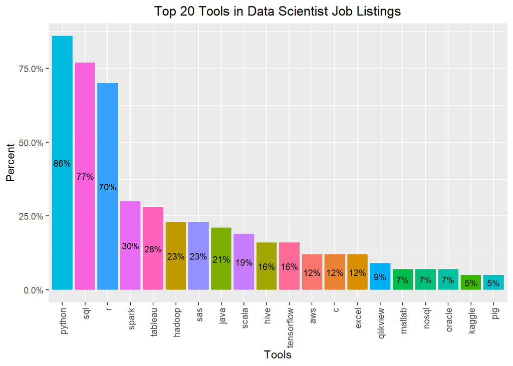

```r
uniqueWords = function(text) {
text <- strsplit(text, " |,|/|;")
text <- lapply(text,unique)
text <- sapply(text, function(u) paste0(u, collapse = " "))
return(text)
}

corpus = tm_map(corpus, content_transformer(uniqueWords))
corpustdm_all <- as.matrix(TermDocumentMatrix(corpus,control=list(wordLengths=c(1,Inf))))

freq <- rowSums(as.matrix(corpustdm_all))
#freq[ as.character(tolower(data.tools[,])) ]

m <- as.matrix(freq[ as.character(tolower(data.tools[,])) ])
n <- as.data.frame(rownames(m))
colnames(n) <- c("toolname")
n$frequency <- round(as.numeric(as.character(m[,1]))/ncol(corpustdm_all),2)
n <- na.omit(n)
#n <- subset(n,frequency>0.1)
n <- head(n[order(n$frequency, decreasing= T),], n = 20)

mycolors = colorRampPalette(brewer.pal(name="Blues", n = 12))(20)
#mycolors = c(brewer.pal(name="Dark2", n = 8), brewer.pal(name="Paired", n = 7))

ggplot(data=n, aes(x= reorder(n$toolname,-frequency), y=n$frequency, fill = n$toolname)) +
  geom_bar(stat="identity")+
  scale_y_continuous(labels = scales::percent) +
  geom_text(aes(label = paste0(frequency*100,"%")),
  position = position_stack(vjust = 0.5), size = 3) +
  scale_color_manual(values = mycolors) +
  theme(legend.position="none") +
  labs(x = "Tools", y = "Percent") +
  ggtitle("Top 20 Tools in Data Scientist Job Listings") +
  theme(plot.title = element_text(hjust=0.5)) +
  ggpubr::rotate_x_text()
```

# 8 Results

## 8.1 Findings

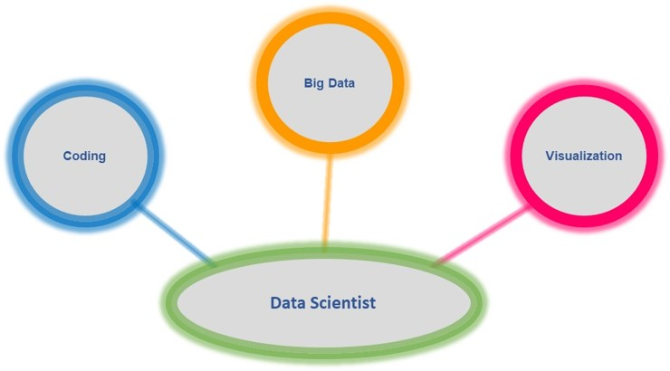

```r
# 5.3 Plot the model
```

## 8.2 Suggestions

- To see **5 Free Online Courses** to Learn Big Data, Hadoop, and Spark in 2019.

Please review the post from [javinpaul.](https://medium.com/swlh/5-free-online-courses-to-learn-big-data-hadoop-and-spark-in-2019-a553e6ccfe30)

- Another great article from the CIO.com website and posted by Thor Olavsrud is **26 big data certifications** that will pay off.

[Click here to read it.](https://www.cio.com/article/3209911/big-data-certifications-that-will-pay-off.html)

# 9 What is Next

- **Incoporate an API to retrieve job postings automatically.**
- **Use geographic visualization to show insigths based on locations.**
- **Predict salaries by using job post data.**